# Toward a Multidimensional CDI-CAT: Noun/Predicate Lexical Category Bias

George Kachergis

2026-09-16

# Motivation

The existing Japanese CDI-CAT (`adaptive_cdi_production.Rmd`) estimates a single, unidimensional production-vocabulary ability. A collaborator (Hiromichi Hagihara, Osaka University) is interested in a companion measure of **lexical category bias**: whether a child’s vocabulary leans toward nouns or toward predicates (verbs and adjectives), relative to what would be expected from their overall vocabulary size. This is motivated by Hagihara, Tan, & Frank’s submitted cross-linguistic paper (“Lexical category biases in children’s early vocabulary”), which finds systematic, cross-linguistically variable noun/verb/adjective biases, and specifically notes that many resources (including, by default, Wordbank’s own `lexical_category` coding) collapse verbs and adjectives into a single “predicates” class for languages – Japanese among them – where adjectives conjugate like verbs.

This document summarizes the pipeline built to support a **multidimensional CAT** that adaptively estimates general vocabulary ability *and* a noun-vs-predicate bias score, from data prep through a first CAT simulation. Scripts referenced below live in `multidim/01` through `multidim/05`; this document does not refit any models – it loads their saved output.

```r
items <- read_csv(here("multidim/item_lexical_categories.csv"), show_col_types = FALSE)
efa_loadings <- read_csv(here("multidim/efa2_loadings.csv"), show_col_types = FALSE)
bifactor_items <- read_csv(here("multidim/bifactor_item_params.csv"), show_col_types = FALSE)
bifactor_scores <- read_csv(here("multidim/bifactor_scores.csv"), show_col_types = FALSE)
cat_summary_wrule <- read_csv(here("multidim/cat_simulation_summary.csv"), show_col_types = FALSE) %>%
  mutate(criteria = "Wrule")
criteria_comparison <- read_csv(here("multidim/criteria_comparison_full_sample.csv"), show_col_types = FALSE)
resp_data <- readRDS(here("multidim/noun_predicate_response_data.Rds"))
sim_results_drule <- readRDS(here("multidim/cat_simulation_results_drule.Rds"))
```

# 1. Item classification

All 711 production-vocabulary items are classified into `nouns`, `verbs`, `adjectives`, `function_words`, or `other` from their CDI semantic category (`category_en`), following the same category → class mapping Wordbank uses for Japanese (verified directly against `wordbankr::get_item_data(language = "Japanese", form = "WS")$lexical_category`, which folds verbs and adjectives into “predicates”). The `pos2` column collapses verbs+adjectives into `predicate`, which is the 2-dimensional split used for the CAT below.

```r
items %>%
  count(lexical_class, pos2) %>%
  arrange(pos2) %>%
  kable(col.names = c("Lexical class", "CAT dimension (pos2)", "N items"),
        caption = "Item counts by lexical class and by the 2-dimensional CAT grouping.") %>%
  kable_styling(full_width = FALSE)
```

Item counts by lexical class and by the 2-dimensional CAT grouping.

| Lexical class | CAT dimension (pos2) | N items |
| --- | --- | --- |
| noun | noun | 312 |
| function_word | other | 81 |
| other | other | 152 |
| adjective | predicate | 63 |
| verb | predicate | 103 |

The item bank used for the multidimensional model is the **478 noun + predicate items** (312 nouns, 166 predicates = 103 verbs + 63 adjectives); function words and the residual “other” category (233 items) are excluded, since neither should carry a noun/predicate-specific signal.

# 2. Sample

The response data are the same combined WG+WS production dataset and exclusion criteria used for the existing unidimensional CAT (`adaptive_cdi_production.Rmd`): administrations from children <12 or >38 months, non-producers ≥12 months, and children at ceiling are dropped, leaving **939** administrations (**639** WS, **300** WG). 12.6% of noun/predicate item responses were missing (mostly WS-only items on WG-form administrations) and were imputed from each child’s fitted bifactor scores (`mirt::imputeMissing()`) before running the CAT simulation.

# 3. Exploratory factor check

Before committing to a confirmatory structure, an exploratory 2-factor IRT model (`mirt`, oblimin rotation) was fit to the 478-item noun+predicate matrix, as a check on whether the a priori noun/predicate split is empirically recoverable.

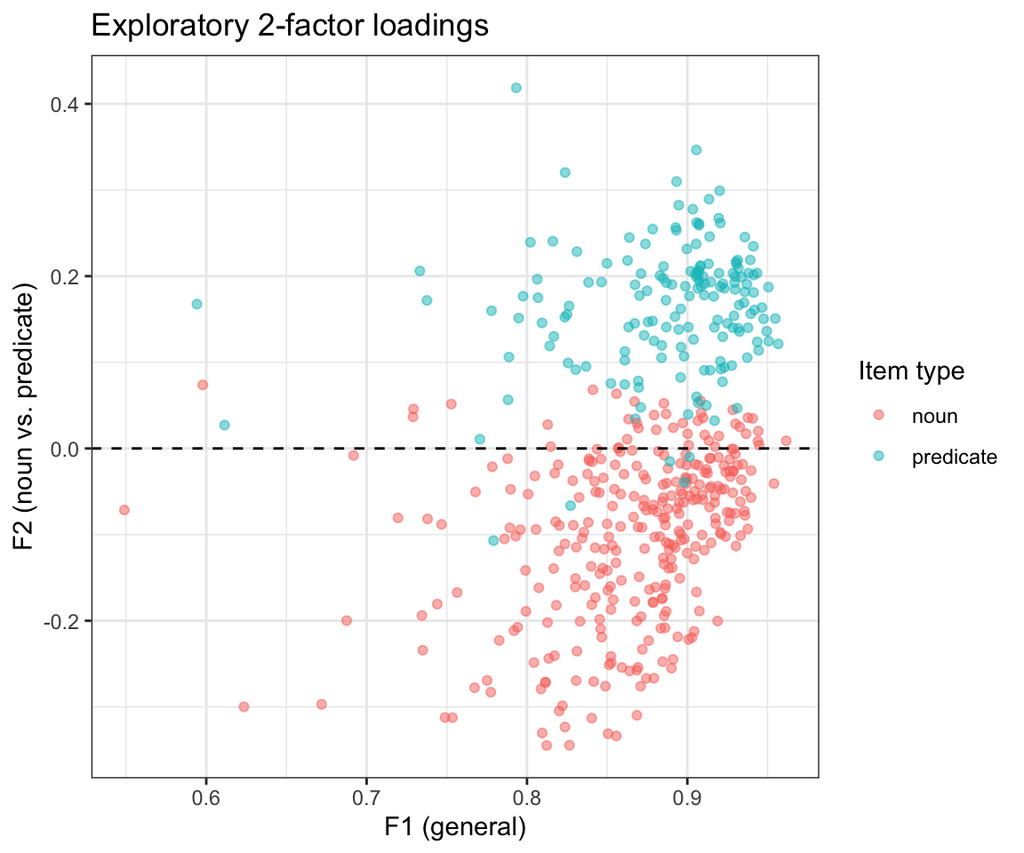

```r
ggplot(efa_loadings, aes(x = F1, y = F2, color = pos2)) +
  geom_point(alpha = 0.5) +
  geom_hline(yintercept = 0, linetype = "dashed") +
  labs(x = "F1 (general)", y = "F2 (noun vs. predicate)", color = "Item type",
       title = "Exploratory 2-factor loadings") +
  theme_bw()
```

```r
efa_loadings %>%
  filter(pos2 %in% c("noun", "predicate")) %>%
  group_by(pos2) %>%
  summarise(mean_F1 = mean(F1), mean_F2 = mean(F2), n = n()) %>%
  kable(digits = 3, caption = "Mean rotated loadings by item type.") %>%
  kable_styling(full_width = FALSE)
```

Mean rotated loadings by item type.

| pos2 | mean_F1 | mean_F2 | n |
| --- | --- | --- | --- |
| noun | 0.865 | -0.101 | 312 |
| predicate | 0.887 | 0.163 | 166 |

**Every item’s dominant loading is on F1** (range 0.55-0.96) – a general vocabulary factor, exactly as expected given raw noun/predicate production proportions correlate r=.94 with each other and r > .97 with total vocabulary size (the “availability problem” the source paper explicitly warns about: raw category proportions are mostly just overall vocabulary size in disguise). F2 is a real but much smaller factor: predicate items load positively (mean 0.163) and noun items negatively (mean -0.101), a highly reliable separation (Welch t = -32.8, p < .0001), and F1/F2 came out nearly orthogonal after rotation (r = -0.015) without being constrained to be. This is exactly the signature of a **bifactor** structure – one dominant general factor plus a much smaller, genuinely separable specific factor – so that was fit next as the confirmatory model.

# 4. Confirmatory bifactor model

`mirt::bfactor()` was fit with every item loading on a general factor (G) plus one of two orthogonal specific factors: S1 (nouns only) or S2 (predicates only). The bias measure of interest is **S1 - S2** per child.

```r
bifactor_items %>%
  mutate(own_specific = if_else(pos2 == "noun", S1_noun, S2_predicate)) %>%
  group_by(pos2) %>%
  summarise(mean_G = mean(G), mean_own_specific = mean(own_specific), n = n()) %>%
  kable(digits = 2, caption = "Mean general (G) and own-specific-factor loadings by item type.") %>%
  kable_styling(full_width = FALSE)
```

Mean general (G) and own-specific-factor loadings by item type.

| pos2 | mean_G | mean_own_specific | n |
| --- | --- | --- | --- |
| noun | 5.33 | 1.20 | 312 |
| predicate | 5.88 | 1.72 | 166 |

```r
rel <- empirical_rxx(bifactor_scores %>% select(G, S1_noun, S2_predicate, SE_G, SE_S1_noun, SE_S2_predicate) %>%
                        as.matrix())
tibble(dimension = names(rel), empirical_rxx = rel) %>%
  kable(digits = 2, caption = "Empirical reliability of full-item-bank (non-adaptive) factor scores.") %>%
  kable_styling(full_width = FALSE)
```

Empirical reliability of full-item-bank (non-adaptive) factor scores.

| dimension | empirical_rxx |
| --- | --- |
| G | 0.93 |
| S1_noun | 0.71 |
| S2_predicate | 0.64 |

The key validation: does the bias score actually separate from general vocabulary size, unlike the raw proportions?

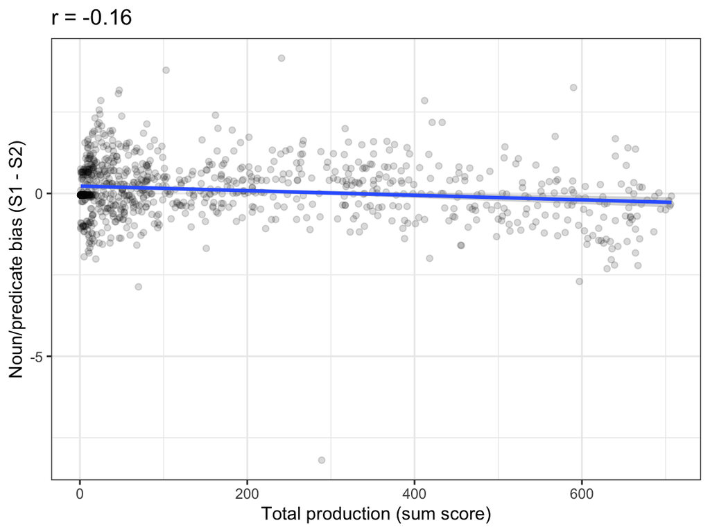

```r
bifactor_scores <- bifactor_scores %>% mutate(noun_predicate_bias = S1_noun - S2_predicate)

ggplot(bifactor_scores, aes(x = production, y = noun_predicate_bias)) +
  geom_point(alpha = 0.15) +
  geom_smooth(method = "lm", se = TRUE) +
  labs(x = "Total production (sum score)", y = "Noun/predicate bias (S1 - S2)",
       title = sprintf("r = %.2f", cor(bifactor_scores$production, bifactor_scores$noun_predicate_bias))) +
  theme_bw()
```

Raw noun/predicate proportions correlated r ≈ .94-.99 with total vocabulary size; the bifactor bias score correlates only **r = -0.16** with production and **r = -0.17** with age – confirming the specific factor is capturing a residual tilt, not just vocabulary size in disguise.

One caveat: although S1 and S2 are constrained to be latently orthogonal in the model, their *EAP score estimates* still correlate r = 0.48 – a known bifactor artifact (shared estimation noise across items), which means the practical precision of the bias *difference* score is worse than either specific factor’s own reliability suggests.

# 5. CAT simulation

## 5.1 Item selection criterion: Drule vs. Wrule

Two multidimensional item-selection criteria were compared: `Drule` (maximizes the determinant of the full 3-D information matrix) and `Wrule` with weights `c(0,1,1)` (explicitly down-weights G, on the hypothesis that the specific factors would otherwise be starved of items since G’s loadings are 3-5x larger). That hypothesis turned out to be wrong:

```r
criteria_comparison %>%
  kable(digits = 3, caption = "Drule vs. Wrule, full N=939 sample, matched max_items ceilings.") %>%
  kable_styling(full_width = FALSE)
```

Drule vs. Wrule, full N=939 sample, matched max_items ceilings.

| criteria | max_items | mean_n_items | mean_SE_G | mean_SE_S1 | mean_SE_S2 | r_bias_vs_full | r_G_vs_full |
| --- | --- | --- | --- | --- | --- | --- | --- |
| Drule | 100 | 75.241 | 0.208 | 0.639 | 0.629 | 0.932 | 0.989 |
| Wrule | 100 | 98.027 | 0.224 | 0.652 | 0.660 | 0.929 | 0.983 |
| Drule | 200 | 131.185 | 0.204 | 0.631 | 0.621 | 0.947 | 0.990 |
| Wrule | 200 | 161.583 | 0.212 | 0.627 | 0.629 | 0.967 | 0.987 |

Drule reaches comparable-or-better specific-factor precision using noticeably **fewer items on average** than Wrule at the same ceiling – once G is well-estimated, conditioning on it is what actually helps resolve S1/S2, so items chosen for general informativeness end up serving the bias dimensions better than items chosen to deliberately avoid G. **Drule is used from here on.**

## 5.2 Achievable precision ceiling

Even a full, non-adaptive 478-item administration only reaches a fairly modest specific-factor precision (Section 4’s reliability table: SE ≈ 0.5 for S1/S2, vs. ≈ 0.17 for G) – substantially worse than can be reached for general ability, and worse than the min_SEM = 0.3 target used for G in the existing unidimensional CAT. The CAT simulation below uses `min_SEM = c(0.3, 0.5, 0.5)`, grounded in that ceiling, rather than an arbitrary tighter target the bias dimensions could never reach.

## 5.3 Simulation results (Drule, full N = 939 sample)

```r
criteria_comparison %>%
  filter(criteria == "Drule") %>%
  bind_rows(cat_summary_wrule %>% filter(max_items == 50) %>%
              transmute(criteria, max_items, mean_n_items, mean_SE_G = mean_SE_G,
                        mean_SE_S1 = mean_SE_S1, mean_SE_S2 = mean_SE_S2,
                        r_bias_vs_full = r_bias_vs_full, r_G_vs_full = r_G_vs_full)) %>%
  arrange(max_items) %>%
  kable(digits = 3,
        caption = "CAT simulation results: item budget vs. recovered precision and agreement with the full-item-bank estimate.") %>%
  kable_styling(full_width = FALSE)
```

CAT simulation results: item budget vs. recovered precision and agreement with the full-item-bank estimate.

| criteria | max_items | mean_n_items | mean_SE_G | mean_SE_S1 | mean_SE_S2 | r_bias_vs_full | r_G_vs_full |
| --- | --- | --- | --- | --- | --- | --- | --- |
| Wrule | 50 | 50.000 | 0.260 | 0.720 | 0.735 | 0.866 | 0.968 |
| Drule | 100 | 75.241 | 0.208 | 0.639 | 0.629 | 0.932 | 0.989 |
| Drule | 200 | 131.185 | 0.204 | 0.631 | 0.621 | 0.947 | 0.990 |

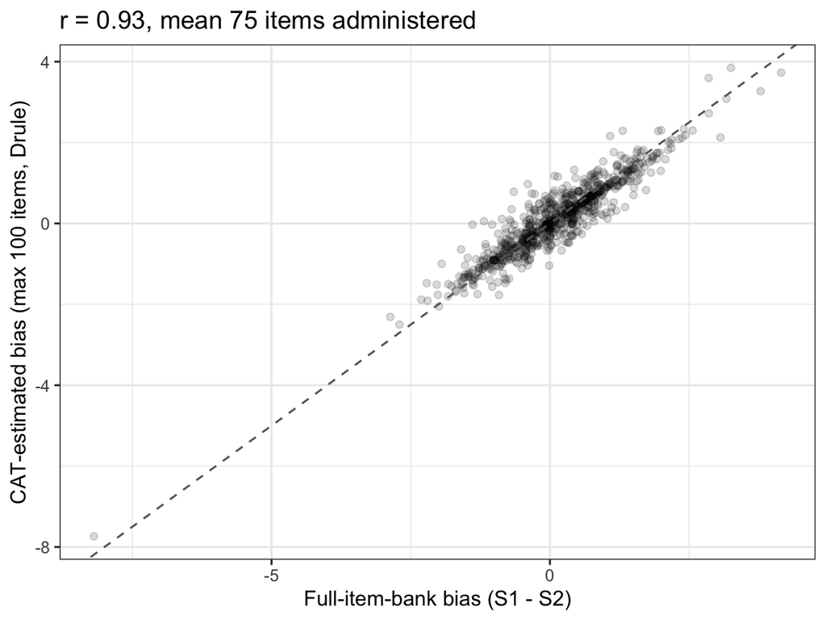

```r
d_demo <- resp_data$d_demo
p100 <- sim_results_drule[["100"]]$parms
p100$data_id <- d_demo$data_id
p100 <- left_join(p100, bifactor_scores %>% select(data_id, bias_full = noun_predicate_bias), by = "data_id")

ggplot(p100, aes(x = bias_full, y = bias_cat)) +
  geom_point(alpha = 0.15) +
  geom_abline(slope = 1, intercept = 0, linetype = "dashed", color = "grey40") +
  labs(x = "Full-item-bank bias (S1 - S2)", y = "CAT-estimated bias (max 100 items, Drule)",
       title = sprintf("r = %.2f, mean %.0f items administered", cor(p100$bias_cat, p100$bias_full), mean(p100$n_items))) +
  theme_bw()
```

With a **100-item ceiling**, Drule administers 75 items on average and recovers the bias score at **r = .93** against the full 478-item estimate; extending the ceiling to 200 items (131 administered on average) reaches **r = .95**. For comparison, the existing unidimensional production CAT gets away with ~25-50 items total because it only has to resolve one dimension – the bias dimension is intrinsically harder to measure precisely, so a noun/predicate-bias CAT will need a substantially larger item budget than the existing vocabulary-size CAT to reach comparable fidelity.

# 6. Summary and open questions

- **Item bank**: 478 items (312 noun, 166 predicate) reliably classified from existing CDI category metadata – no new item coding was needed.
- **Model**: a bifactor structure (general vocabulary factor + orthogonal noun-specific and predicate-specific factors) is empirically supported (the EFA check found a dominant general factor plus a small, real, near-orthogonal secondary noun/predicate split) and successfully decouples the bias score from vocabulary size/age (r ≈ -.16, down from r ≈ .94-.99 for raw proportions).
- **CAT**: `Drule` item selection with `min_SEM = c(0.3, 0.5, 0.5)`; a ~100-item budget recovers the bias estimate at r = .93 vs. the full item bank, ~200 items reaches r = .95.

Open questions worth settling with Hiromichi before further development:

1. **Deployment stopping rule**: fixed item count (~100-150) vs. adaptive SE-based stopping – the latter is principled but a meaningful fraction of children will still hit the item ceiling given the precision ceiling in Section 5.2.
2. **3-way split**: whether to pursue nouns/verbs/adjectives as three specific factors instead of the 2-way noun/predicate collapse used here (the source paper’s own adjective bias was the noisiest and least typologically predictable of the three categories, so a 3-way model may need more items per dimension than are available, but it would match the paper’s own finer-grained distinction).
3. Whether a shorter, purpose-built noun/predicate-only CAT (this document) should be a standalone instrument, or whether it’s preferable to fold these dimensions into a single administration alongside the existing production CAT (sharing items, one longer adaptive session instead of two).